# PREDICTING SALES VOLUMES

Oriol Ordi and Alejandro Rojo

2/12/2019

# Introduction

This report will show the sales predictions in four different product types and their relationship with service and costumer reviews. For this purpose multipl regression will be used to build machine learning models running three different algorithms (*K-NN*, *SVM* and *Random Forest*).

#### Objectives

- Predict sales of four different product types: PC, Laptops, Netbooks and Smartphones.
- Explain the services and customer reviews impact on sales of different product types.
- Find and/or build the variables which better predicts sales volume.
- Make recommendations to the sales department based in our results.

#### Materials

For the development of this exercise the data sets provided by Danielle Sherman via e-mail in .csv format will be used, consisting of the following documents:

- *existingprodutattributes2017.csv* – This csv file contains information about product features, reviews and historical sales information. This file will be used to build the predictive models.
- *newproductattributtes2017.csv* – This csv file contains information about product features and reviews, but no sales information. This is the data set where the model will be used to make the sales predictions.

# Data Exploration

#### Missing values

The existing products dataset has 15 observations that contain missing values (NA). Since removing 15 observations in a 80 row dataset is removing too much data, and considering that all missing values are in the same attribute (*BestSellersRank*), the best action is to remove that attribute to deal with the missing values.

#### Outliers

Most of the attributes have outliers, some of them a high number of outliers. Removing all the outliers fro all the attributes would result in reducing the dataset to almost no observations.  
Therefore, only the outliers in the target variable (2 observations) are removed.

#### Duplicates

The dataset presents a few rows that are duplicated, except for the price and (obviously) the product number. These rows are all corresponding to the *ProductType* “Extended Warranty” and they are assumed to be different versions of the same product.  
Thus, to avoid overfitting of the observations, the duplicated values are all but one removed, and the remaining observation is used with the *Price* set to the mean of all prices in the duplicated observations.

#### Missing Reviews

There are 3 observations that have “missing” *Star Reviews*, meaning that all the star attributes (*x4StarReviews*, *x3StarReviews*, *x2StarReviews*, *x1StarReviews*) are 0.

Since the nature of this missing data is not known, it is safer to remove those observations from the dataset.

#### Abnormal Observations

Plotting the *Volume* against various indepenent variables shows some interesting insights, namely that there are some observations that don’t align at all with the rest. One example of this can be seen in the next figure, where the highest value of *x1StarReviews* doesn’t align at all with the rest.

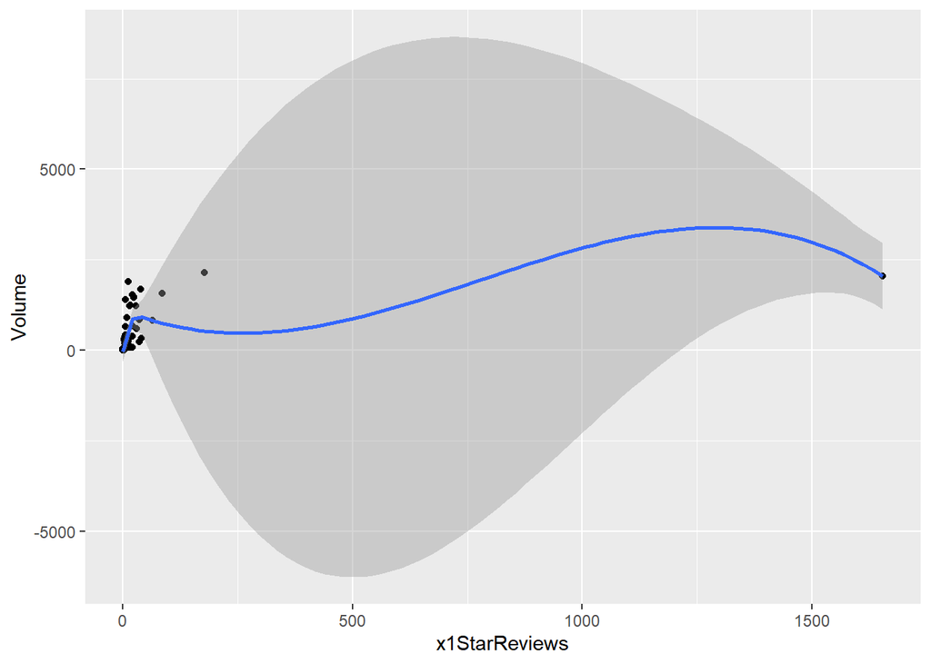

The observations that don’t align for the model are, thus, removed from the dataset.

#### Correlation

To check correlation, including the *ProductType*, the first thing that has to be done is to dummify the *ProductType*.  
Once the *ProductType* is dummified, the correlation between variables can be checked:

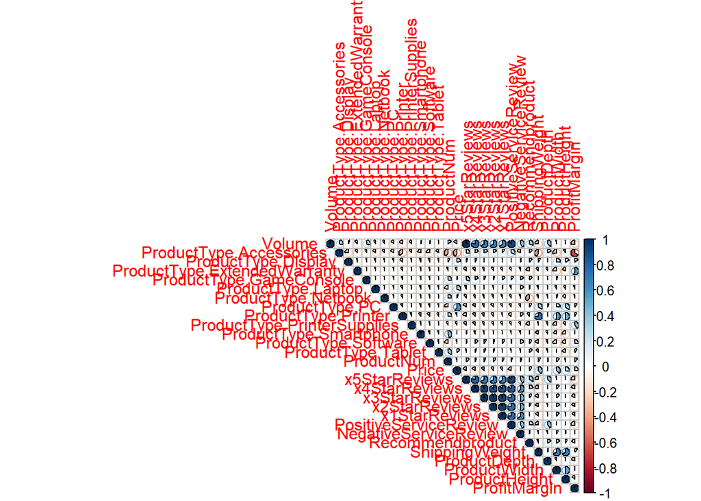

In the correlation plot it can be seen that none of the *Product Types* are correlated with the *Volume*. The next figure asserts this affirmation:

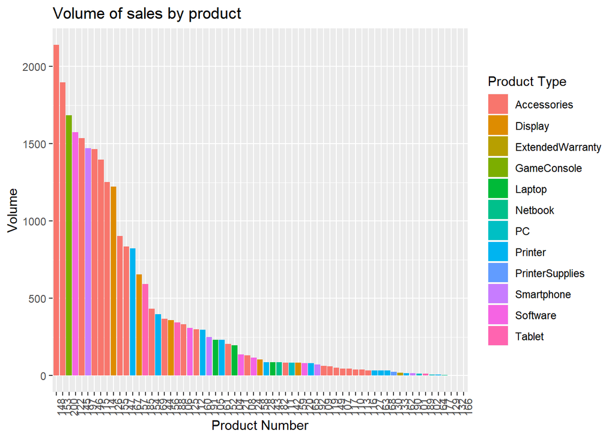

In the last figure, the sales *Volume* are shown by *Product Number*, grouped (colored) by *Product Type* in descending order. As it can be seen, the color distribution is spread out, meaning that there is little relation between the *Product Types* and the sales *Volume*.

Once the correlation between *Volume* and *Product Type* is assumed to be nonexistent, the correlation between other attributes and *Volume* are checked, as well as the collinearity between attributes, and the correlations higher than 0.85 are selected to take into consideration:

```
##              id                   key     value
## 1        Volume         x5StarReviews 1.0000000
## 2 x4StarReviews         x3StarReviews 0.9348952
## 3 x4StarReviews         x2StarReviews 0.8975588
## 4 x3StarReviews         x2StarReviews 0.9706185
## 5 x4StarReviews         x1StarReviews 0.8723360
## 6 x3StarReviews         x1StarReviews 0.9362148
## 7 x2StarReviews         x1StarReviews 0.9391297
## 8        Volume PositiveServiceReview 0.9105237
## 9 x5StarReviews PositiveServiceReview 0.9105237
```

After so much data preprocessing and eliminating observations, the variables start to show high collinearity.

First of all, the *x5StarReviews* has a correlation coefficient of 1 with the target variable, meaning that, most likely, the data was tampered with and this attribute should not be trusted.

Then, as the correlation coefficients show, all the *Star Review* attributes are highly collinear.

Besides that, it is noteworthy that the *PositiveServiceReview* attribute has high correlation with the target variable and, thus, it is possibly the best suited to explain the model.

The *Star Review* variables have also semi-high correlation with the target variable, but, since they are all collinear, only one of them can be used. In this case, it will be the *x4StarReviews*, which is the most correlated with the *Volume*.

#### Feature engineering

New features have been built and tried with the goal of finding if there are better predictors for sales volume. Various combinations of different attributes (e.g. *Product Volume*, *Density*, the difference between *Positive Service Reviews* and *Negative Service Reviews*, different forms of variable scaling, etc.).

# Modelling

To find a model that best suits the data, several algorithms (namely *K-nn*, *Random Forest* and *SVM*) are used on various combinations of variables.

For the sake of simplification, only a few relevant variables are included in the following plot (although many more have been tried).